# Informe No. 2

Santiago Alvarez, José Aristizabal, Angie López, Helber Padilla, José David Restrepo y Karen Rivera.

15 de octubre de 2018

## REQUISITOS DEL CLIENTE

El número de autos registrados diarimente en Colombia puede ser de importancia para bancos y organismos de tránsito con el fin de predecir cual será el volumen de ventas de autos en cierto periodo de tiempo, y de esta forma generar estrategias de marketing, en el caso de los bancos para saber cual será el posible número de clientes nuevos potenciales para créditos de libre inversión. Al 2016 el RUNT contaba con mas de 5.558.984 de autos registrados, y en el mismo año se vendieron 238.238 unidades.

## DESCRIPCION DE VARIABLES

- Dia:Día del mes.
- Dia.semana:Dia de la semana.
- Mes:Mes del año.
- Empleo:Tasa de empleo diario en Colombia.
- Desempleo:Tasa de desempleo diaria en Colombia.
- Dolar:Precio del dolar diario en Colombia .
- Minimo:Salario Minimo en colombia.
- Inflación: Variable que indica la inflación por día en colombia.

A continuación se presenta un encabezado de la base de datos a usar:

Resumen de la base de datos

|  | Año | Dia | Mes | Día semana | Unidades | Empleo | Desempleo | Dolar | Minimo | Inflacion |
| --- | --- | --- | --- | --- | --- | --- | --- | --- | --- | --- |
| 1 | 2012 | 1 | Enero | Domingo | 0 | 56 | 12,5 | 1942,7 | 566700 | 3,5 |
| 2 | 2012 | 2 | Enero | Lunes | 188 | 56 | 12,5 | 1942,7 | 566700 | 3,5 |
| 3 | 2012 | 3 | Enero | Martes | 482 | 56 | 12,5 | 1942,7 | 566700 | 3,5 |
| 4 | 2012 | 4 | Enero | Miércoles | 927 | 56 | 12,5 | 1915,0 | 566700 | 3,5 |
| 5 | 2012 | 5 | Enero | Jueves | 1159 | 56 | 12,5 | 1898,2 | 566700 | 3,5 |
| 6 | 2012 | 6 | Enero | Viernes | 996 | 56 | 12,5 | 1884,4 | 566700 | 3,5 |
| 7 | 2012 | 7 | Enero | Sábado | 243 | 56 | 12,5 | 1884,5 | 566700 | 3,5 |
| 8 | 2012 | 8 | Enero | Domingo | 0 | 56 | 12,5 | 1884,5 | 566700 | 3,5 |
| 9 | 2012 | 9 | Enero | Lunes | 0 | 56 | 12,5 | 1884,5 | 566700 | 3,5 |
| 10 | 2012 | 10 | Enero | Martes | 697 | 56 | 12,5 | 1884,5 | 566700 | 3,5 |
| 11 | 2012 | 11 | Enero | Miércoles | 956 | 56 | 12,5 | 1865,1 | 566700 | 3,5 |
| 12 | 2012 | 12 | Enero | Jueves | 1001 | 56 | 12,5 | 1854,2 | 566700 | 3,5 |
| 13 | 2012 | 13 | Enero | Viernes | 1170 | 56 | 12,5 | 1842,5 | 566700 | 3,5 |
| 14 | 2012 | 14 | Enero | Sábado | 372 | 56 | 12,5 | 1841,3 | 566700 | 3,5 |
| 15 | 2012 | 15 | Enero | Domingo | 1 | 56 | 12,5 | 1841,3 | 566700 | 3,5 |

# Descripción de la variable respuesta

La variable que se busca explicar con el modelo propuesto en este trabajo es el “Número de Autos Registrados diariamente en el RUNT”, por la naturaleza de los datos(conteo), se decidio modelar la variable respuesta con una distribución Poisson.

Las variables utilizadas como explicativas de la respuesta en el modelamiento se identificaron heuristicamente, considerando que podrían tener sentido en el contexto del problema de investigación.

#### Gráfico 1

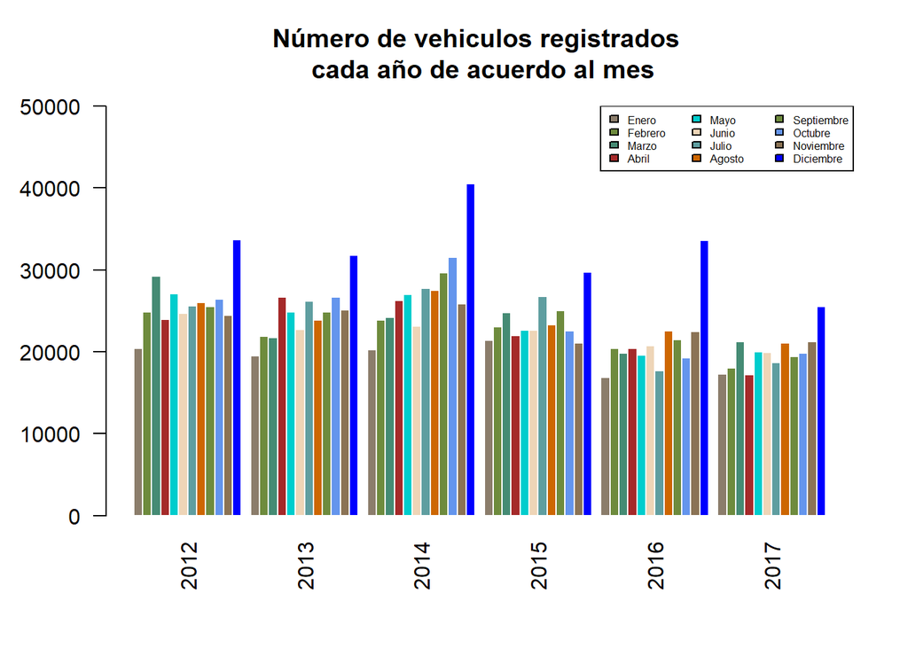

#### Gráfico 2

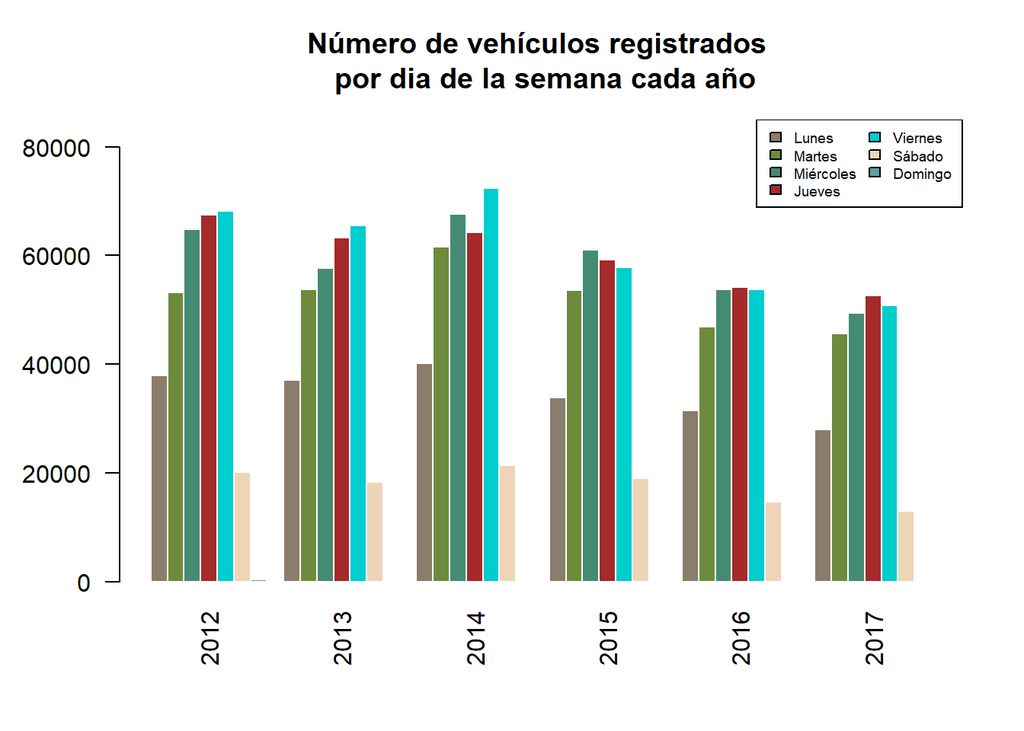

De acuerdo al gráfico 1 se observa que consistentemente año tras año, en los primeres meses del año se registran menos vehículos y en diciembre se presenta este suceso en mayor medida, también se evidencia del gráfico 2 que en los fines de semana, año tras año, el registro de vehículos presenta la menor cantidad de autos registrados, y es miércoles, jueves, y viernes donde alcanza los mayores registros.

#### Gráfico 3

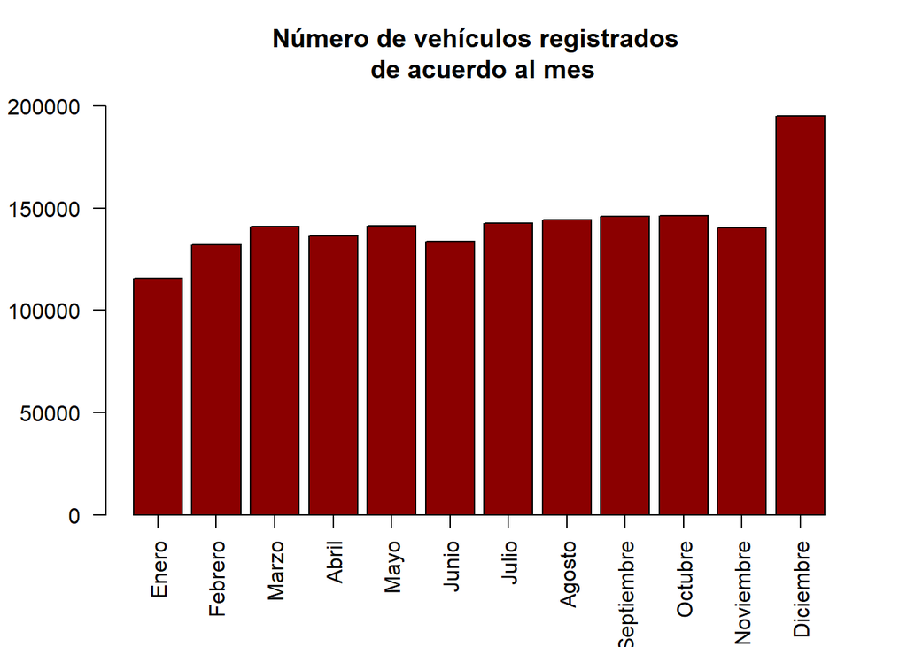

#### Gráfico 4

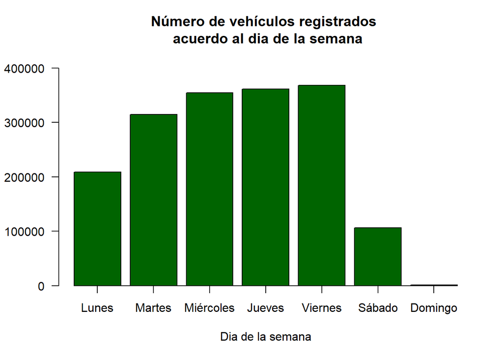

#### Gráfico 5

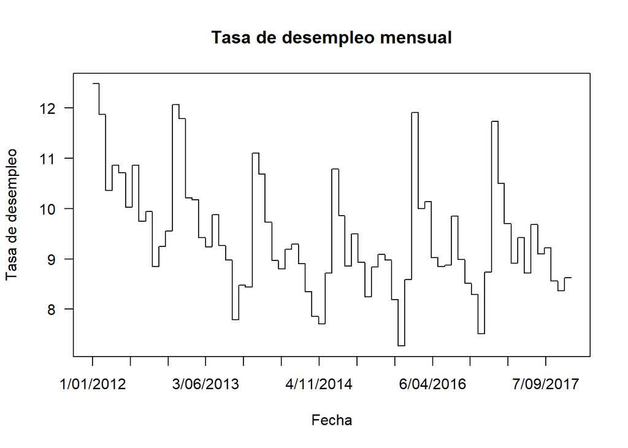

En los gráficos 3 y 4 se observa que estos comportamientos al ocurrir año tras año también representan un patrón global. En el gráfico 5, se muestra la tasa de desempleo mensual en Colombia, y se observa un patrón inverso al del número de vehículos registrados mensualmente. A menudo la gente consigue trabajos temporales en diciembre que incrementan su capacidad adquisitiva y puede que esta sea reflejada en la compra de un vehículo, un inmueble, entre otros, mientras que en enero (y en los primeros meses del año) es donde se empiezan a pagar las deudas adquiridas en el mes de diciembre inmediatamente anterior.

#### Gráfico 6

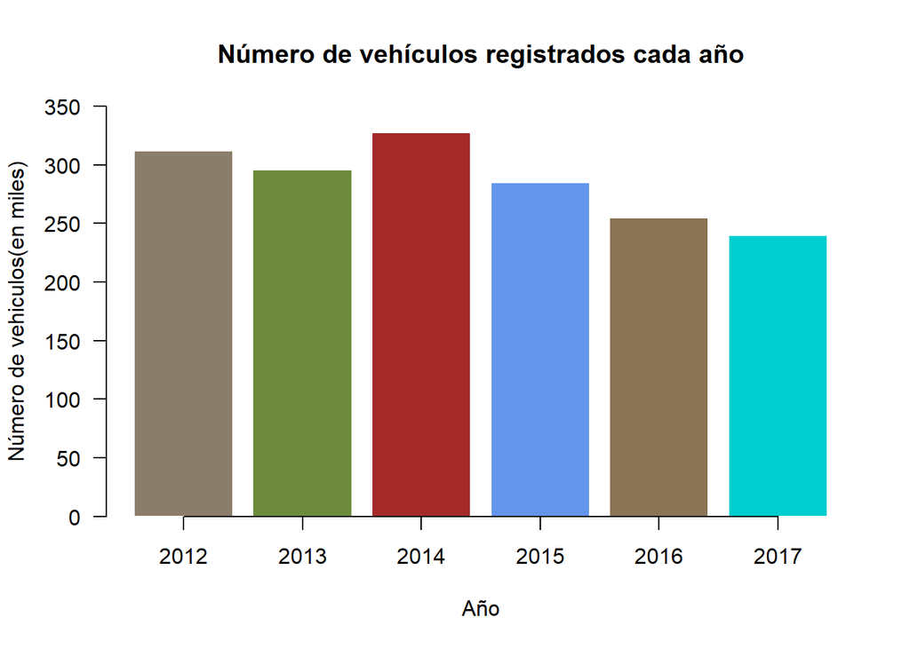

#### Gráfico 7

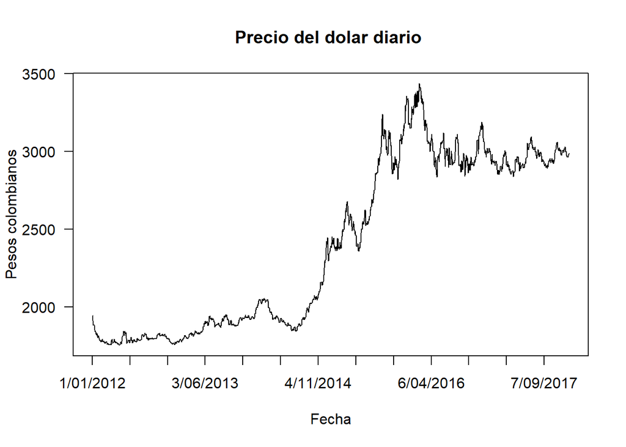

#### Gráfico 8

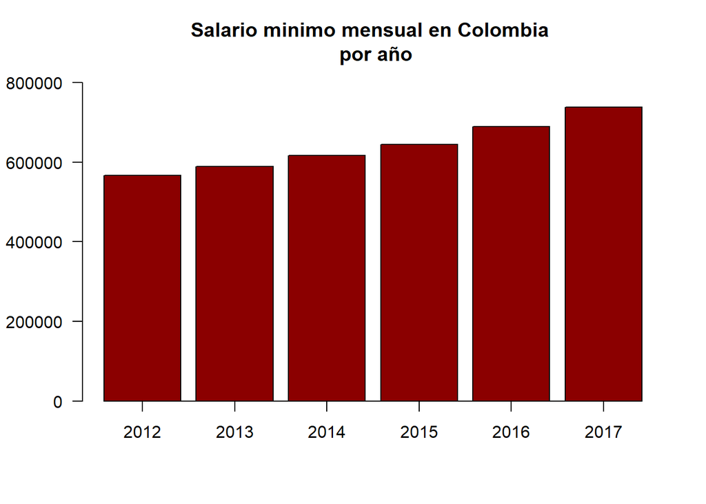

En el gráfico 6 se observa que en los años 2016 y 2017 disminuyó el número de vehículos registrados con respecto a los anteriores, esto posiblemente se debe al alza del dolar durante el 2015 (gráfico 7) como consecuencia de la recuperación de la economía estadounidense tras la crisis del 2008-2009 y cuyos efectos apenas empezaban a desaparecer a mediados del 2014. El incremento en el precio del dolar ocasiona una disminución en la capacidad de compra pues los precios de la mercancía importada aumentan mientras que el salario, al menos relativamente, no presenta un aumento significativamente grande cada año (gráfico 8)

## MODELAMIENTO

Como se mencionó anteriormente la variable respuesta es el “Número de Autos Registrados diariamente en el RUNT”, la cual cuenta con la caracteristica de ser no negativa y discreta.

Para este modelamiento se escogió un Modelo Lineal Generalizado (GLM), el cual es una generalización de los modelos de regresión y presenta una reunión de modelos de regresión lineal, modelos de regresión logistica y de regresión Poisson.

En la regresión Poisson las variables que se usan como predictoras pueden ser continuas o categóricas, mientras que la respuesta se modela como un conteo, además los modelos GLM se componen de tres elementos:

- Una función de distribución perteneciente a la familia de la exponencial, (componente aleatoria).
- Un predictor lineal $\eta=X\beta$, (componente sistematica).
- Una función de enlace $g$, tal que $E(Y)=\mu=g^{-1}(\eta)$

Esta distribución en unimodal y su propiedad más destacada es que la media y la varianza coinciden. $E(Y)=Var(Y)=\mu$, sin embargo, cuando se trabaja con recuentos reales no suele ser cierta hipótesis. Con frecuencia la varianza es mayor que la media. A esto se le llama *sobredispersión*

En R se pueden ajustar estos modelos gracias a la función ‘glm’ del paquete ‘stats’.

# ANALISIS DE LA VARIABLE RESPUESTA

A continuación se presenta un gráfico de dispersión de la variable respuesta

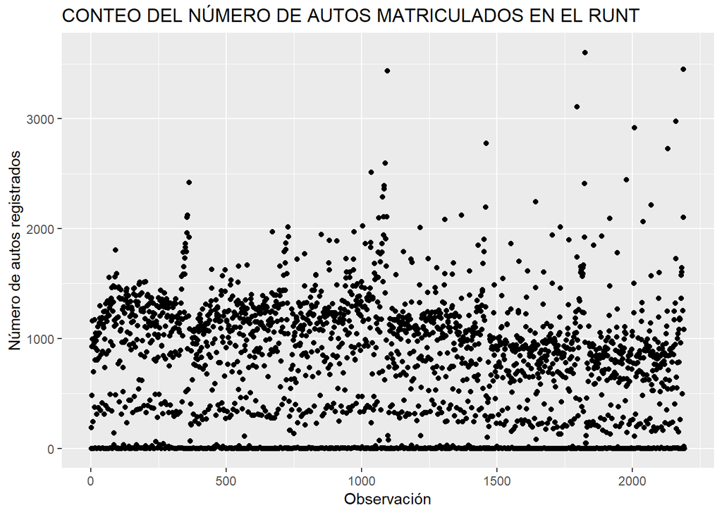

Es evidente una gran cantidad de ceros, lo cual puede ser un indicio de que es aceptable ajustar un modelo *glm*, por otro lado, se observa una gran dispersión de los datos.

Como se esperaba, la varianza es mucho más grande que la media indicando así sobredispersión en los datos.

| Media | Varianza |
| --- | --- |
| 782,2 | 303782,6 |

# AJUSTE DEL MODELO USANDO “TRAINING AND VERIFICATION DATA”

Cuando se tienen grandes volumenes de datos, una forma de ajustar un modelo es particionando la base de datos en entrenamiento y verificación, el objetivo de este método consiste en dividir los datos de tal modo que con la parte de entrenamiento se ajuste el modelo y con la parte de verificación se verfique la capacidad del modelo de hacer predicciones. En este caso, la base se particionara del año 2012-2016 y 2017 como entrenamiento y validación respectivamente.

```
##
## Call:
## glm(formula = unidades ~ año + dia + mes + dia.semana + empleo +
##     desempleo + dolar + minimo + inflacion, family = poisson,
##     data = Entrenamiento)
##
## Deviance Residuals:
##     Min       1Q   Median       3Q      Max
## -63.097   -2.914   -0.389    4.343   42.867
##
## Coefficients:
##                           Estimate     Std. Error z value
## (Intercept)         -89.8776628988  14.6899103059  -6.118
## año                   0.0447656170   0.0073681744   6.076
## dia                   0.0152298045   0.0000942484 161.592
## mesAgosto            -0.0238343087   0.0043965845  -5.421
## mesDiciembre          0.2890649621   0.0049239651  58.706
## mesEnero             -0.1532387355   0.0067674914 -22.643
## mesFebrero            0.0859251806   0.0052479767  16.373
## mesJulio              0.0132287292   0.0041973126   3.152
## mesJunio             -0.0536592288   0.0044491432 -12.061
## mesMarzo              0.0213366792   0.0045754852   4.663
## mesMayo              -0.0523561293   0.0042043743 -12.453
## mesNoviembre         -0.0662277733   0.0063513183 -10.427
## mesOctubre           -0.1156594104   0.0070539555 -16.396
## mesSeptiembre         0.0597225648   0.0047160293  12.664
## dia.semanaJueves      5.8983781930   0.0344239649 171.345
## dia.semanaLunes       5.3595172353   0.0344572702 155.541
## dia.semanaMartes      5.7600702430   0.0344308651 167.294
## dia.semanaMiércoles   5.8866656663   0.0344245009 171.002
## dia.semanaSábado      4.7032786567   0.0345320620 136.200
## dia.semanaViernes     5.9292973004   0.0344225960 172.250
## empleo                0.0387626434   0.0023420679  16.551
## desempleo            -0.0142818182   0.0031126539  -4.588
## dolar                -0.0000730848   0.0000060158 -12.149
## minimo               -0.0000020270   0.0000002387  -8.491
## inflacion            -0.0150345236   0.0014461185 -10.396
##                                 Pr(>|z|)
## (Intercept)               0.000000000946 ***
## año                       0.000000001236 ***
```

[output cut: 18 more lines]

```
## empleo              < 0.0000000000000002 ***
## desempleo                 0.000004468507 ***
## dolar               < 0.0000000000000002 ***
## minimo              < 0.0000000000000002 ***
## inflacion           < 0.0000000000000002 ***
## ---
## Signif. codes:  0 '***' 0.001 '**' 0.01 '*' 0.05 '.' 0.1 ' ' 1
##
## (Dispersion parameter for poisson family taken to be 1)
##
##     Null deviance: 913454  on 1826  degrees of freedom
## Residual deviance: 220302  on 1802  degrees of freedom
## AIC: 233488
##
## Number of Fisher Scoring iterations: 6
```

Se observa que todas las variables son significativas, dando indicios de un buen ajuste del modelo.

CORRELACIÓN ENTRE VALORES AJUSTADOS Y VARIABLE RESPUESTA

La correlación es una medida que indica que tan bien describe los datos el modelo ajustado, para valores muy cercanos a 1 indica buen ajuste.

| Correlación |
| --- |
| 0,8540746 |

El $R^2$ de *McFadden* ajustado es una medida del tamaño del efecto para la prueba de comparación de modelo.

| PseudoR2 |
| --- |
| 0,7480676 |

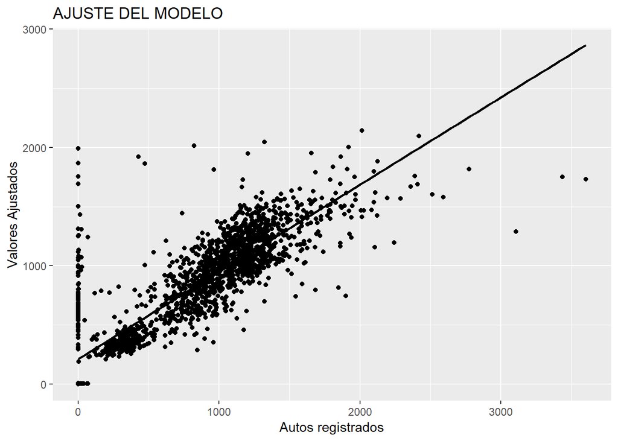

En este gráfico se evidencia un buen ajuste, ya que los datos siguen la tendencia de la linea recta.

# VALIDACIÓN

A continuación se presentan los gráficos de validación.

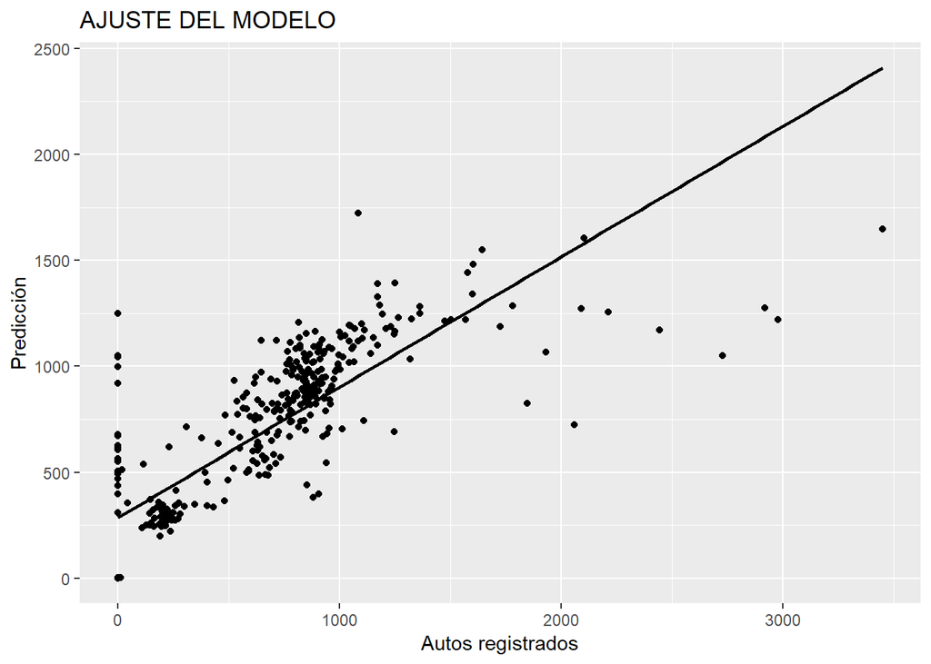

| Correlación |
| --- |
| 0,8008159 |

#### CONCLUSIÓN

Como conclusión del modelo se considera bueno en ajuste, en cuanto a predicción la correlación fue evidente que disminuyó, esto puede ser debido como tal a la sobredispersión que se encuentra en la variable respuesta y esto pudo haber interferido en que el modelo ajustara mucho mejor. En general, sigue siendo un buen modelo tanto en ajuste como en predicción.